# Mini Project 2

Hayat Hussein

2024-04-15

# Introduction

The research question we are examining is whether the number of days physical health was not good is greater in males, compared to females. This research is important to study, because we need to discover if there are factors that contribute to a specific sexes physical health. We also need to determine if there is a significant difference in the number of days physical health was not good in males than in females. By discovering this data, we may be able to address the health issues presented in males if true, and use resources to address the large gap.

This research may impact people such as healthcare providers, administrators, researchers, and patients, as this data may be used to create improvement within the healthcare community. This data can be used to improve patient outcomes, address patient needs, allow researchers to study health disparities presented within data, and allow patients to be informed and strengthen their health information behavior patterns. Primary stakeholders include healthcare professionals that are involved with this data firsthand, as well as healthcare administrators that have the power to allocate resources to different people depending on results. Secondary stakeholders include research groups who study the data outcomes and identify key findings within their research.

The results will impact patient care in an institutional setting by improving and enhancing efficacy within clinical trials, supporting various intervention methods, and creating significant discoveries created within health research. By this study, we can identify key factors in physical health, and whether or not there is a greater difference in the number of days males have not good physical health days compared to females. In a research article authored by Nass from the Institute of Medicine, the researcher asserts that, “Collectively, these forms of health research have led to significant discoveries, the development of new therapies, and a remarkable improvement in health care and public health” (Nass 2009). This displays the impact this research question will have amongst the health community.

# Data Cleaning & Exploratory Data Analysis

The data that is being used for this analysis is the Behavioral Risk Factor Surveilliance System from the year 2010, and the type of data source is a health related telephone survey. The first step I took was making sure the appropriate packages were installed and then importing the necessary packages for this data. I then imported the brfss data and verified the variable recodings worked by using cross tabs. The dataset consisted of 3260 observations and 397 variables. 59 is the mean of the physical health variable. 69% of the patients in the dataset were female and 31% of patients in the dataset were males.

# Data Visualization

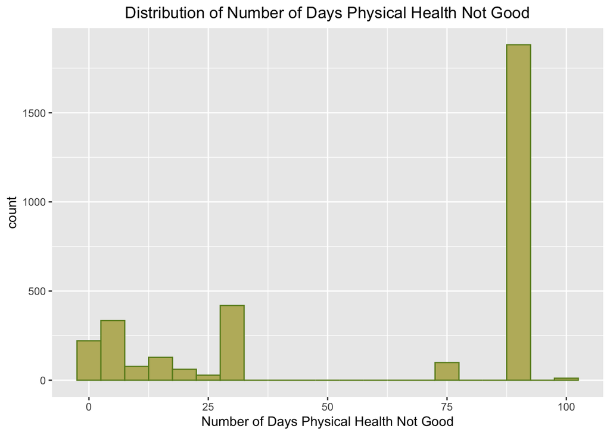

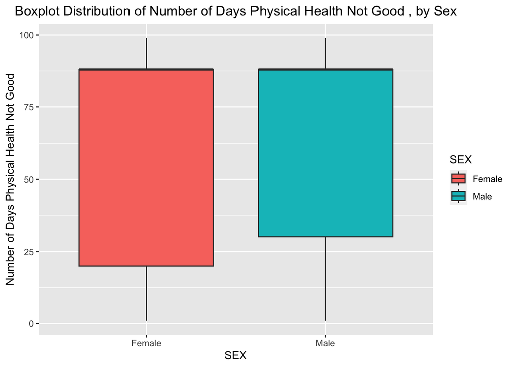

# Hypothesis Test

The null hypothesis is the the Number of Days Physical Health was Not Good between males and females is the same. The alternative hypothesis is the Number of Days Physical Health was Not Good is greater in males, compared to females. The alpha is set at 0.05 and the type of test s upper tailed. The p-value is 0.0003965.

# Conclusion